# An example code for generating processed Seurat object for scViewer App

Abhijeet R. Patil, Ph.D.

2023-04-28

```r
knitr::opts_chunk$set(echo = TRUE)
knitr::opts_knit$set(root.dir = 'E:/Users/APATIL34/GSE157827_RAW/sub/')
options(future.globals.maxSize = 1000000 * 1024^2)
```

### Supplementary code documentation for scViewer manuscript.

### scViewer: An interactive single-cell gene expression visualization tool

### Abhijeet R. Patil*, Gaurav Kumar, Huanyu Zhou, Liling Warren

### SCD Statistics, Teva Pharmaceuticals

In this document, we show the single-cell data processing workflow and storing metadata information into the Seurat object to make it available to use in the app.

# Section 1- Load packages/libraries for processing single-cell data

### The methods/tools we incorporated in this single-cell data processing script are popularly used methods in single-cell field. Users can use other packages that contain different methodologies for loading, pre-processing, normalization, doublet finding, and annotation steps. The only requirement for running the app is the proper naming protocol for columns in the metadata information which is highlighted in the below workflow.

Here, we will load the required libraries for the processing the data. The **Seurat** and **sctransform** packages are used for processing the data. We used the **scDblFinder** package for identifying and removing doublets in the dataset. Finally, we used the marker based **scSorter** method for annotating the cells.

```r
library("sctransform")
library("cowplot")
# theme_set(theme_cowplot())
library("RColorBrewer")
library("viridis")
library("kableExtra")
library("knitr")
library("viridisLite")
library("tidyverse")
library('Seurat')
library('ggplot2')
library('tidyverse')
library('gridExtra')
library('dplyr')
library('data.table')
library('magrittr')
library("BiocParallel")
library("SingleCellExperiment")
library("viridis")
library("scSorter")
library("patchwork")
library("scDblFinder")
library("glmGamPoi")
```

# Section 2- Load data

Here we are loading the data from raw matrices uploaded in GSE157827 (https://www.ncbi.nlm.nih.gov/geo/query/acc.cgi?acc=GSE157827). There are 21 samples in this dataset including 12 samples from Alzheimer’s disease and 9 samples Normal groups.

We downloaded the data and stored in a directory. Within this directory we created seperate sub-directories for storing files from each sample. Below we access the list of the sub-directories where the data is stored.

```r
## Get the directories where the data is stored
dirs <- list.dirs(path = './', recursive = F, full.names = F)
dirs
```

```
##  [1] "GSM4775561_AD1"  "GSM4775562_AD2"  "GSM4775563_AD4"  "GSM4775564_AD5"
##  [5] "GSM4775565_AD6"  "GSM4775566_AD8"  "GSM4775567_AD9"  "GSM4775568_AD10"
##  [9] "GSM4775569_AD13" "GSM4775570_AD19" "GSM4775571_AD20" "GSM4775572_AD21"
## [13] "GSM4775573_NC3"  "GSM4775574_NC7"  "GSM4775575_NC11" "GSM4775576_NC12"
## [17] "GSM4775577_NC14" "GSM4775578_NC15" "GSM4775579_NC16" "GSM4775580_NC17"
## [21] "GSM4775581_NC18"
```

Below we show how the files are stored within in each directory

```r
print(list.files(path = "./GSM4775561_AD1/"))
```

```
## [1] "barcodes.tsv.gz" "features.tsv.gz" "matrix.mtx.gz"
```

## First, we will load the count matrices for individual samples and preprocess the data to create Seurat object.

The Seurat object initialization step where the **min.cells**- parameter will include genes detected in at least 3 cells. The **min.features** - Include cells where at least 200 genes are detected.

```r
for(x in dirs){
  # name <- gsub('_filtered_feature_bc_matrix','', x)

  cts <- ReadMtx(mtx = paste0('./',x,'/matrix.mtx.gz'),
                 features = paste0('./',x,'/features.tsv.gz'),
                 cells = paste0('./',x,'/barcodes.tsv.gz'))

  # create seurat objects
  assign(x, CreateSeuratObject(counts = cts, min.cells = 3, min.features = 200))
}
```

```
## as(<dgTMatrix>, "dgCMatrix") is deprecated since Matrix 1.5-0; do as(., "CsparseMatrix") instead
```

## Next, Merge the above individual datasets. Here, the *Important* step is to define the normal/healthy samples to start-with the word Normal_. For example, GSM4775573_NC3 sample have been named as Normal_3.

The app looks for the keyword (Normal_) to differentiate between Disease and Normal groups.

```r
# merge the above datasets
merged_data <- merge(GSM4775561_AD1, y = c(GSM4775562_AD2,
                                           GSM4775563_AD4,
                                           GSM4775564_AD5,
                                           GSM4775565_AD6,
                                           GSM4775566_AD8,
                                           GSM4775567_AD9,
                                           GSM4775568_AD10,
                                           GSM4775569_AD13,
                                           GSM4775570_AD19,
                                           GSM4775571_AD20,
                                           GSM4775572_AD21,
                                           GSM4775573_NC3,
                                           GSM4775574_NC7,
                                           GSM4775575_NC11,
                                           GSM4775576_NC12,
                                           GSM4775577_NC14,
                                           GSM4775578_NC15,
                                           GSM4775579_NC16,
                                           GSM4775580_NC17,
                                           GSM4775581_NC18),
                       add.cell.ids = c("AD_1", "AD_2", "AD_4", "AD_5", "AD_6", "AD_8", "AD_9", "AD_10",
                                        "AD_13", "AD_19", "AD_20", "AD_21",
                                        "Normal_3", "Normal_7", "Normal_11", "Normal_12", "Normal_14", "Normal_15", "Normal_16", "Normal_17", "Normal_18"),
                       project = 'AD_Normal')
```

## Dimension of raw merged counts matrix

The dimension of the raw counts matrix after merging all the scRNA-seq samples is shown below.

```r
dim(merged_data)
```

```
## [1]  28412 179036
```

# Section 3- Metadata information for running the shiny app

## Add metadata *Important* for the scViewer shiny app

Here, we will add three new columns to the Seurat metadata.

### 1. Column name for disease state- **grp**. For ex, This column will have samples such as AD and NC which represents Alzheimer disease patients and normal controls.

### 2. Column name for samples- **sample_ids**. For ex, This column will have samples such as AD_1, AD_2, NC_1, NC_2 etc. which represents two disease and two healthy patients.

### 3. Column name for cell types- **cell_type**. For ex, This column will have cell types such as Astrocytes, Microglia etc.

Below we add the 1 and 2 from above. The cell types will be added in the cell annotation section.

```r
## Add metadata information
## Add metadata information
## create a tmp_sample column (Extract from rownames- the above merge function stores the samples in the order inserted in the vector)
merged_data$tmp_sample <- rownames(merged_data@meta.data)

## split sample column to create unique IDs (sample) and disease state (grp) columns.
merged_data@meta.data <- separate(merged_data@meta.data, col = 'tmp_sample', into = c('grp', 'sample', 'barcode'),
                                    sep = '_')

## Add unique sample IDs and disease state information to create a new sample_ids column
merged_data$sample_ids <- c(paste0(merged_data$grp, "_", merged_data$sample))

merged_data@meta.data$sample<- NULL
# head(merged_data@meta.data)
```

Show the sample ids and disease groups.

### Table showing metadata information

```r
head(merged_data@meta.data) %>%
  kable(format = "html", col.names = colnames(head(merged_data@meta.data))) %>%
  kable_styling() %>%
  kableExtra::scroll_box(width = "100%", height = "300px")
```

|  | orig.ident | nCount_RNA | nFeature_RNA | grp | barcode | sample_ids |
| --- | --- | --- | --- | --- | --- | --- |
| AD_1_AAACCCAAGCTGAAAT-1 | SeuratProject | 15864 | 4475 | AD | AAACCCAAGCTGAAAT-1 | AD_1 |
| AD_1_AAACCCACAAATGGTA-1 | SeuratProject | 3394 | 1909 | AD | AAACCCACAAATGGTA-1 | AD_1 |
| AD_1_AAACCCACAATGAAAC-1 | SeuratProject | 3136 | 1592 | AD | AAACCCACAATGAAAC-1 | AD_1 |
| AD_1_AAACCCAGTAACCCTA-1 | SeuratProject | 517 | 450 | AD | AAACCCAGTAACCCTA-1 | AD_1 |
| AD_1_AAACCCAGTAGCGAGT-1 | SeuratProject | 3171 | 1764 | AD | AAACCCAGTAGCGAGT-1 | AD_1 |
| AD_1_AAACGAATCAACCGAT-1 | SeuratProject | 4062 | 2082 | AD | AAACGAATCAACCGAT-1 | AD_1 |

```r
## Calculate MT %
merged_data[["percent.mt"]] <- PercentageFeatureSet(merged_data, pattern = "^MT-")
```

## Initial pre-processing

The below violin plots shows the number of features, counts, and mitochondrial reads after loading the data and intial pre-processing.

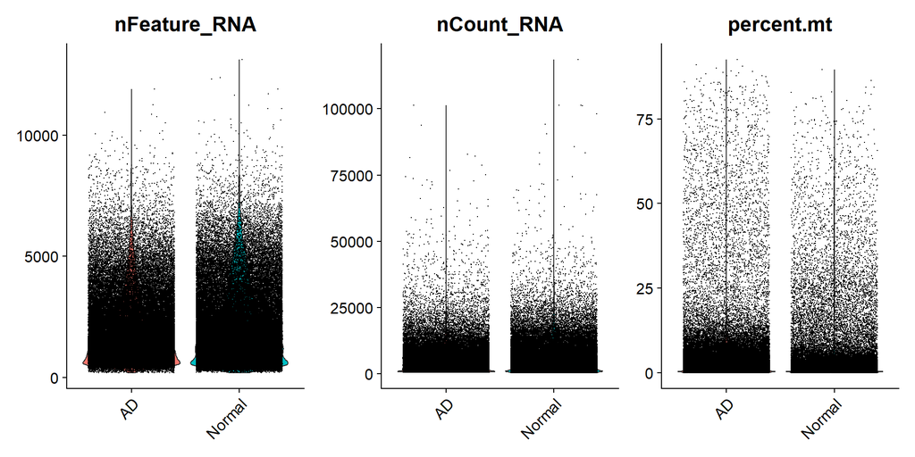

```r
VlnPlot(merged_data, features = c("nFeature_RNA", "nCount_RNA", "percent.mt"), ncol = 3, group.by = "grp",
        pt.size = 0.001, combine = T) & theme(legend.position = 'none',
                                                               axis.title.x = element_blank())
```

Correlation between **nCount_RNA** and **nFeature_RNA**.

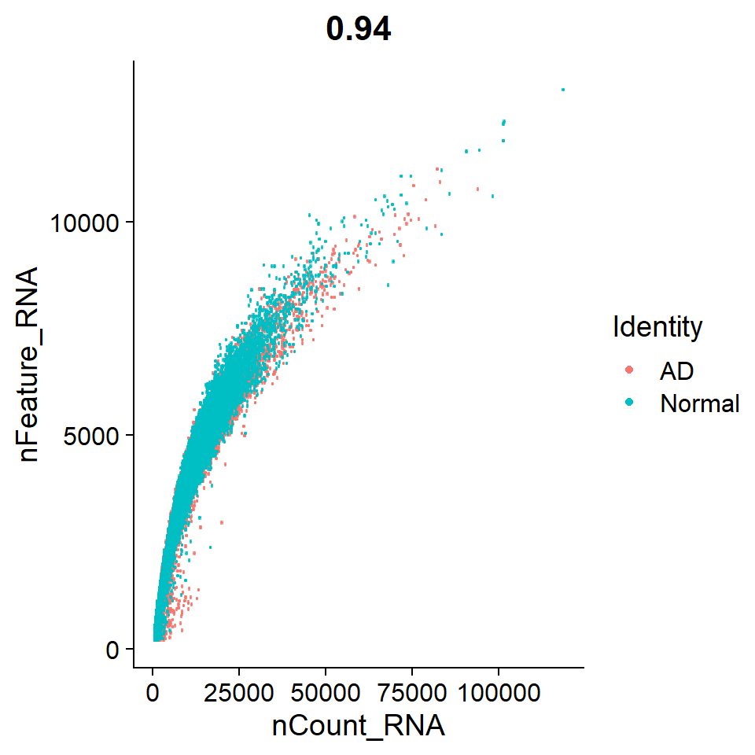

```r
FeatureScatter(merged_data, feature1 = "nCount_RNA", feature2 = "nFeature_RNA", group.by = "grp")
```

## Remove doublets

The **scDblFinder** function is used to remove the potential doublets from each sample separately. The **sample_ids** column refers to individual sample.

```r
## Convert object into singlecellexperiment
merged_data.sce <- as.SingleCellExperiment(merged_data)
merged_data.sce <- scDblFinder(merged_data.sce, samples="sample_ids", clusters=FALSE, BPPARAM=MulticoreParam(10))
## Convert sce object back to seurat
merged_data_seurat <- as.Seurat(merged_data.sce, counts = "counts", data = "logcounts")
```

### The total number of doublets are shown below

```r
table(merged_data.sce$scDblFinder.class)
```

```
##
## singlet doublet
##  157218   21818
```

The doublet information is stored in the metadata. The updated metadata can be found below

### Updated metadata table with doublets information

```r
head(merged_data_seurat@meta.data) %>%
  kable(format = "html", col.names = colnames(head(merged_data_seurat@meta.data))) %>%
  kable_styling() %>%
  kableExtra::scroll_box(width = "100%", height = "300px")
```

|  | orig.ident | nCount_RNA | nFeature_RNA | grp | barcode | sample_ids | percent.mt | ident | scDblFinder.sample | scDblFinder.class | scDblFinder.score | scDblFinder.weighted | scDblFinder.cxds_score |
| --- | --- | --- | --- | --- | --- | --- | --- | --- | --- | --- | --- | --- | --- |
| AD_1_AAACCCAAGCTGAAAT-1 | SeuratProject | 15864 | 4475 | AD | AAACCCAAGCTGAAAT-1 | AD_1 | 0.0693394 | SeuratProject | AD_1 | singlet | 0.0469046 | 0.1425427 | 0.1676816 |
| AD_1_AAACCCACAAATGGTA-1 | SeuratProject | 3394 | 1909 | AD | AAACCCACAAATGGTA-1 | AD_1 | 0.1473188 | SeuratProject | AD_1 | singlet | 0.0024175 | 0.0290698 | 0.0626183 |
| AD_1_AAACCCACAATGAAAC-1 | SeuratProject | 3136 | 1592 | AD | AAACCCACAATGAAAC-1 | AD_1 | 0.3507653 | SeuratProject | AD_1 | singlet | 0.0018822 | 0.0546015 | 0.0823433 |
| AD_1_AAACCCAGTAACCCTA-1 | SeuratProject | 517 | 450 | AD | AAACCCAGTAACCCTA-1 | AD_1 | 5.4158607 | SeuratProject | AD_1 | singlet | 0.0007584 | 0.0000000 | 0.0000000 |
| AD_1_AAACCCAGTAGCGAGT-1 | SeuratProject | 3171 | 1764 | AD | AAACCCAGTAGCGAGT-1 | AD_1 | 0.1576790 | SeuratProject | AD_1 | singlet | 0.0960416 | 0.1375233 | 0.1246630 |
| AD_1_AAACGAATCAACCGAT-1 | SeuratProject | 4062 | 2082 | AD | AAACGAATCAACCGAT-1 | AD_1 | 0.0738552 | SeuratProject | AD_1 | singlet | 0.0033964 | 0.0809586 | 0.0004968 |

## Pre-processing the data based on information from above steps

The nFeature_RNA and nCount_RNA represents the number of genes detected in each cell and the total number of molecules (UMIs) detected within a cell respectively. While the low nFeature_RNA in a cell mean that it may be dead/dying or it may represent an empty droplet, the high nCount_RNA and nFeature_RNA denotes that the cell may be a doublet or multiplet. This filtering along with mitochondrial reads is crucial pre-processing step, because, removing such outliers from these groups might also remove some of the doublets or dead/empty droplets.

### Remove all the potential doublets found

The cell being either doublet or singlet is stored in column scDlFinder.class. The potential doublets are removed in this step.

```r
# After doublet removal
merged_data_v1 <- subset(merged_data_seurat, subset = scDblFinder.class  == "singlet")
```

### Subset Data

The final data after removing potential doublets and subsetting based on nFeature and percent.mt is shown below

```r
merged_data_new <- subset(merged_data_v1, subset = nFeature_RNA > 200 & nFeature_RNA < 7500
                   & percent.mt < 15
                   & nCount_RNA < 75000
)
dim(merged_data_new)
```

```
## [1]  28412 149791
```

## Update Metadata with MT genes information

After removing doublets, now we can proceed with further pre-processing steps. For ex, Mitochondrial genes are useful indicators of cell state.

## After pre-processing

The metadata information is updated after final pre-processing. The violin plot are used to show the number of features, counts, and the percentage of mitochondrial reads after all the pre-processing.

Violin plots showing nFeature_RNA, nCount_RNA, and percent.mt.

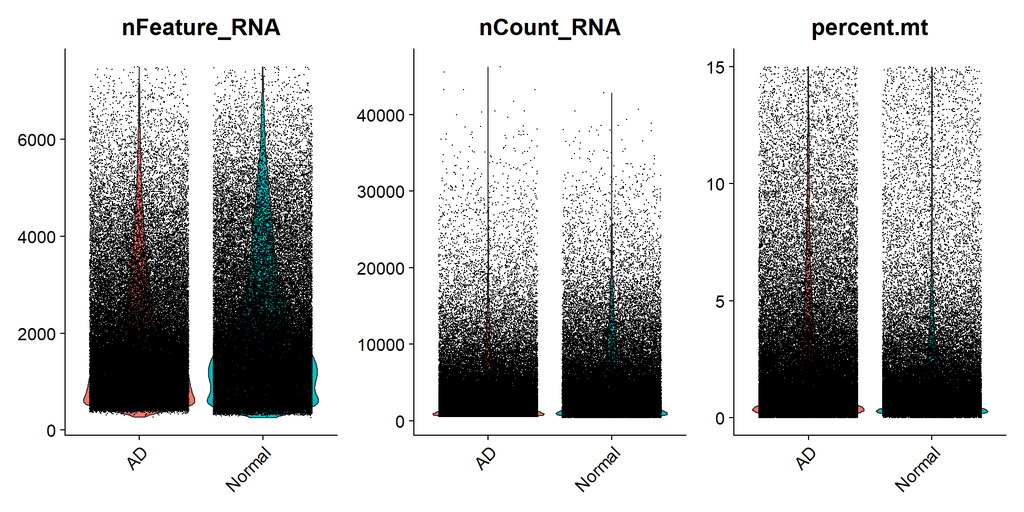

```r
VlnPlot(merged_data_new, features = c("nFeature_RNA", "nCount_RNA", "percent.mt"), ncol = 3, group.by = "grp",
        pt.size = 0.00001, combine = T) & theme(legend.position = 'none',
                                                               axis.title.x = element_blank())
```

### Feature Scatter plots

Correlation between **nCount_RNA** and **nFeature_RNA**.

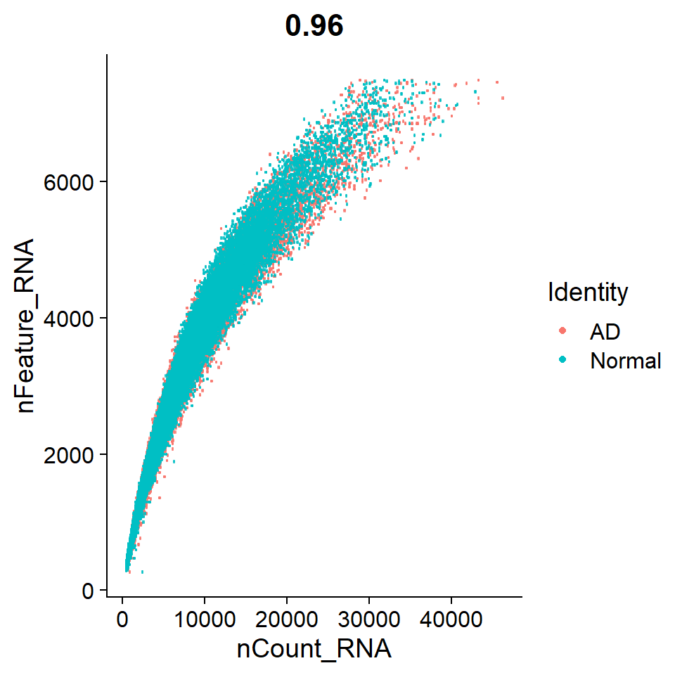

```r
FeatureScatter(merged_data_new, feature1 = "nCount_RNA", feature2 = "nFeature_RNA", group.by = "grp")
```

Median gene number showing the cell distribution across all groups after final pre-processing

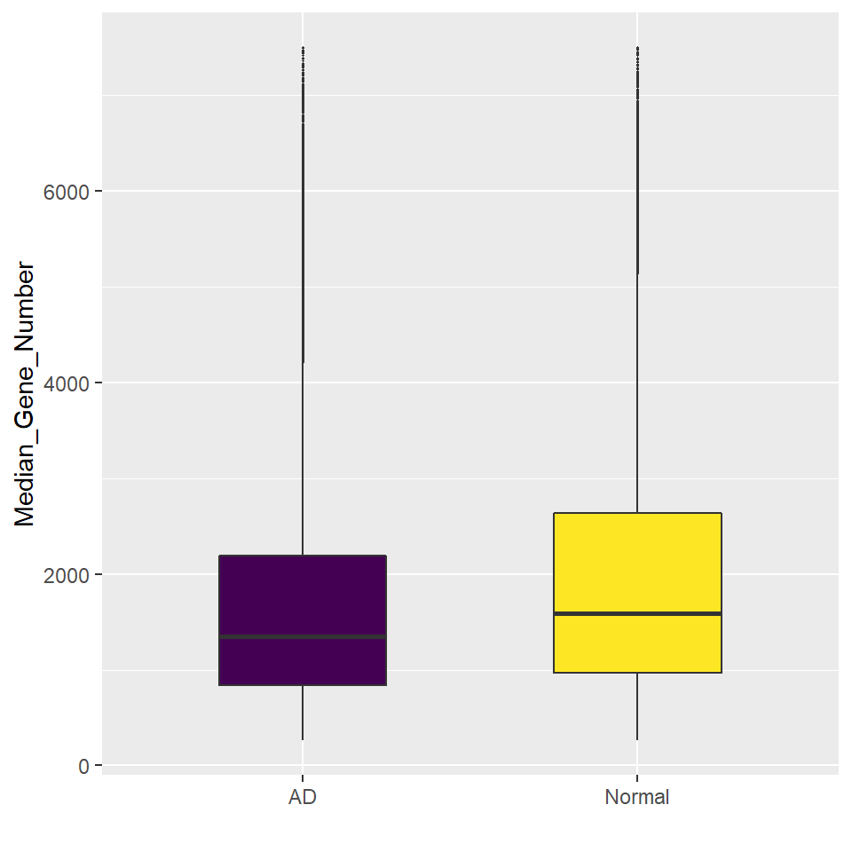

```r
## Median Gene Per Sample after filtering
df_medgen <- data.frame(merged_data_new@meta.data$nFeature_RNA, merged_data_new@meta.data$grp)
colnames(df_medgen) <- c("Median_Gene_Number", "Condition")
ggplot(df_medgen, aes(Condition, Median_Gene_Number)) + geom_boxplot(aes(fill = Condition),
                                                                   width=0.5, outlier.size = 0.2) +
  scale_fill_viridis(discrete = TRUE) + xlab("") + theme(legend.position = "none")
```

```r
# Remove all unused variables
rm(GSM4775561_AD1, GSM4775562_AD2, GSM4775563_AD4, GSM4775564_AD5, GSM4775565_AD6, GSM4775566_AD8, GSM4775567_AD9, GSM4775568_AD10, GSM4775569_AD13, GSM4775570_AD19, GSM4775571_AD20, GSM4775572_AD21, GSM4775573_NC3, GSM4775574_NC7, GSM4775575_NC11, GSM4775576_NC12, GSM4775577_NC14, GSM4775578_NC15, GSM4775579_NC16, GSM4775580_NC17, GSM4775581_NC18)
gc()
```

```
##              used    (Mb) gc trigger    (Mb)   max used    (Mb)
## Ncells    8766441   468.2   17170554   917.1   17170554   917.1
## Vcells 3330619231 25410.7 5560794438 42425.5 4361002025 33271.9
```

```r
rm(merged_data)
rm(cts)
rm(merged_data.sce, merged_data_v1, merged_data_seurat)
gc()
```

```
##             used   (Mb) gc trigger    (Mb)   max used    (Mb)
## Ncells   8703715  464.9   17170554   917.1   17170554   917.1
## Vcells 844710250 6444.7 4448635551 33940.4 4361002025 33271.9
```

# Section 3- Normalizing and scaling the data

## SCT: Single Cell Transform

The SCTransform method is an one stop alternative to the NormalizeData, FindVariableFeatures, ScaleData workflow of Seurat. This function is used to normalize the counts that measures the differences in sequencing depth per cell for each sample. The SCT method uses regularized negative binomial model to perform both normalization and variance stabilization of single-cell RNA-seq data. The SCTransform method removes the variation due to sequencing depth (nUMIs). In addition, the parameter ‘vars.to.regress’ regresses out the variation from other sources such as percentage of mitochondrial. The output of SCT model is the normalized expression levels for all the transcripts. Lastly, the variable.features.n parameter is used to set the number of variable features. The default value is 3000 genes.

```r
merged_data_new_sct <- SCTransform(merged_data_new, method = "glmGamPoi", variable.features.n = 3000, vars.to.regress = "percent.mt", conserve.memory = TRUE, verbose = FALSE)
```

```r
rm(merged_data_new)
gc()
```

```
##              used    (Mb) gc trigger    (Mb)   max used    (Mb)
## Ncells    8790961   469.5   17170554   917.1   17170554   917.1
## Vcells 1927478370 14705.5 5125004154 39100.7 5124988398 39100.6
```

The seurat object now consists of two assays RNA and SCT, with the default being set as SCT.

```r
DefaultAssay(merged_data_new_sct)
```

```
## [1] "SCT"
```

### Perform dimensionality reduction by PCA and UMAP embedding

These are now standard steps in the Seurat workflow for visualization and clustering

```r
merged_data_new_sct <- RunPCA(merged_data_new_sct, verbose = TRUE)
gc() ## To clear up memory
```

```
##              used    (Mb) gc trigger    (Mb)   max used    (Mb)
## Ncells    8793816   469.7   17170554   917.1   17170554   917.1
## Vcells 1935277768 14765.0 5125004154 39100.7 5124988398 39100.6
```

Plot showing the variance explained by PCs from the PCA analysis

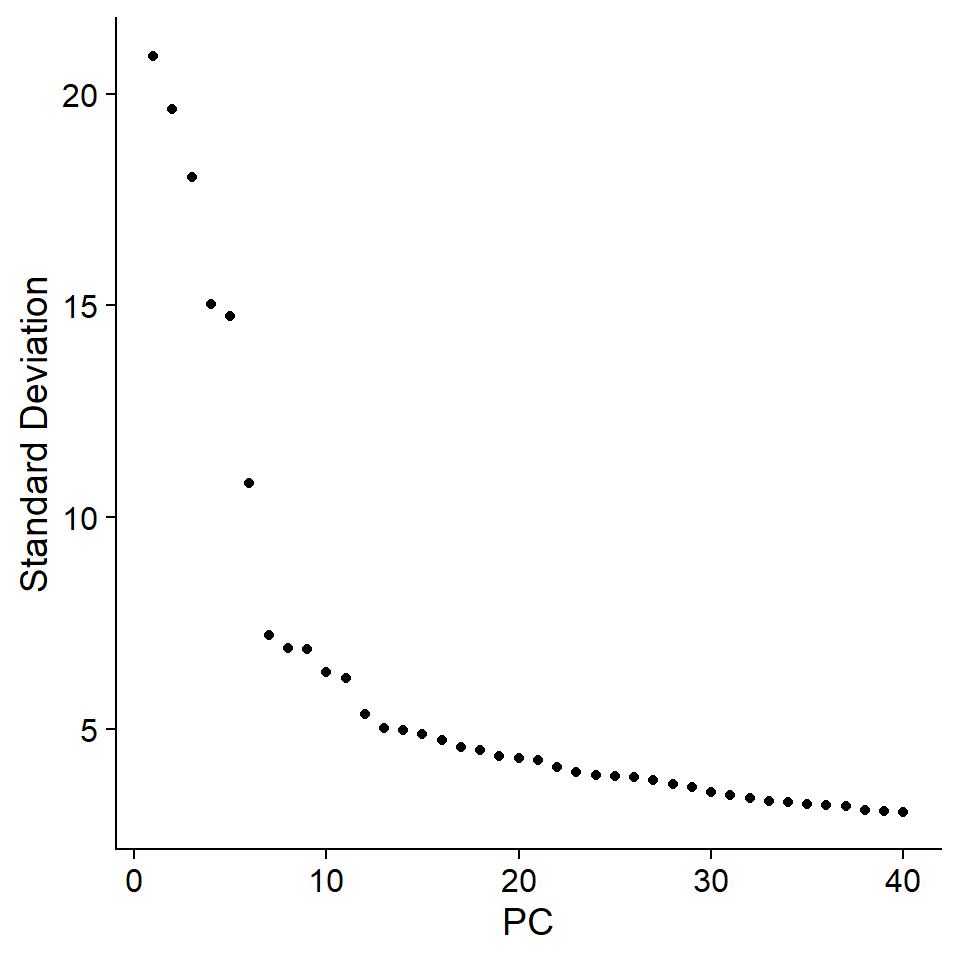

```r
ElbowPlot(merged_data_new_sct, ndims = 40)
# ElbowPlot(merged_data_new_sct)
```

## Run UMAP

The Uniform Manifold Approximation and Projection (UMAP) dimensional reduction technique is run on the first 20 principal components.

```r
merged_data_new_sct <- RunUMAP(merged_data_new_sct, dims = 1:20, verbose = FALSE)
```

## Find Neighbors

Here we compute the k nearest neighbors in the dataset. The nearest neighbors are calculated on the reduced dimensions from the PCA. We use first 20 principal components.

```r
merged_data_new_sct <- FindNeighbors(merged_data_new_sct, dims = 1:20, verbose = FALSE)
```

## Find Clusters

Once we have calculated the k-nearest neighbors in previous step, we will find the clusters of cells by the shared nearest neihbor (SNN) clustering algorithm. Here, we have set the resolution as 0.8. The higher resolution usually gives more number of clusters.

```r
merged_data_new_sct <- FindClusters(merged_data_new_sct, resolution = 0.8, method = "igraph", verbose = FALSE)
gc()
```

```
##              used    (Mb) gc trigger    (Mb)   max used    (Mb)
## Ncells    8823723   471.3   17170554   917.1   17170554   917.1
## Vcells 1956523230 14927.1 5125004154 39100.7 5124988398 39100.6
```

## UMAP plotting

UMAP plot showing the clusters based on SCT data and snn optimization at resolution 0.8

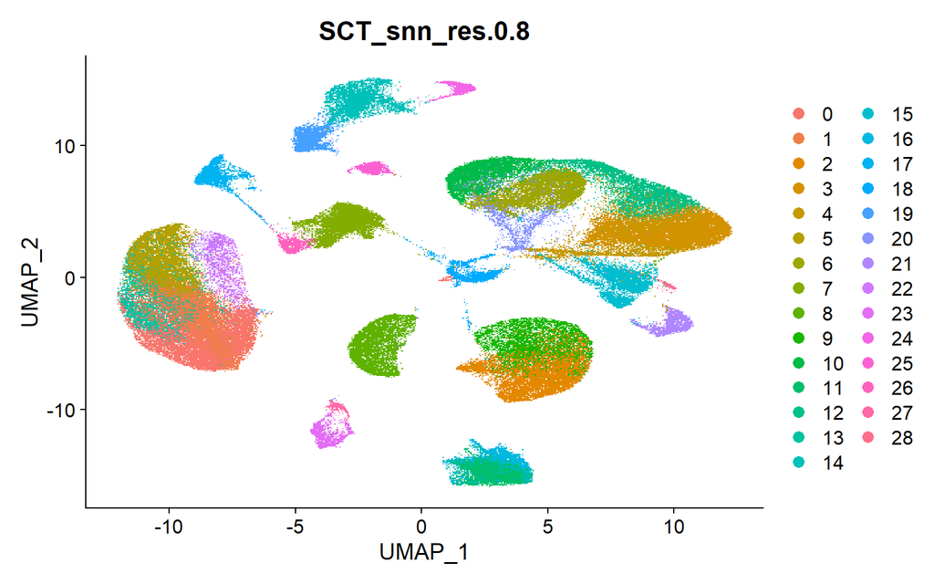

```r
DimPlot(merged_data_new_sct, group.by='SCT_snn_res.0.8', reduction='umap') +
  ggtitle('SCT_snn_res.0.8')
```

UMAP plot showing the distribution of cells across different disease types.

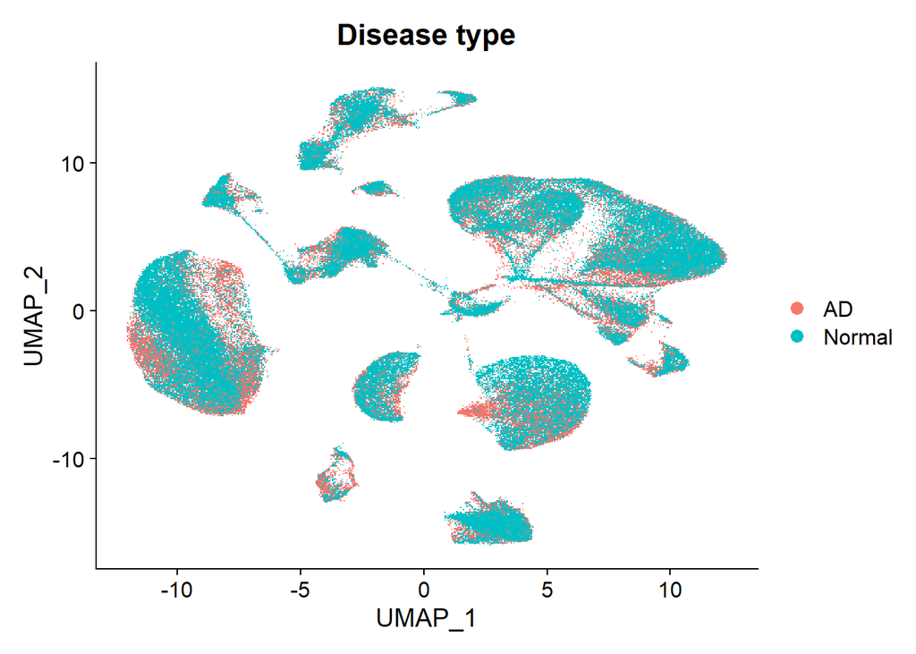

```r
DimPlot(merged_data_new_sct, group.by='grp', reduction='umap') +
  ggtitle('Disease type')
```

UMAP plot showing the cell distribution with respect to individual donors

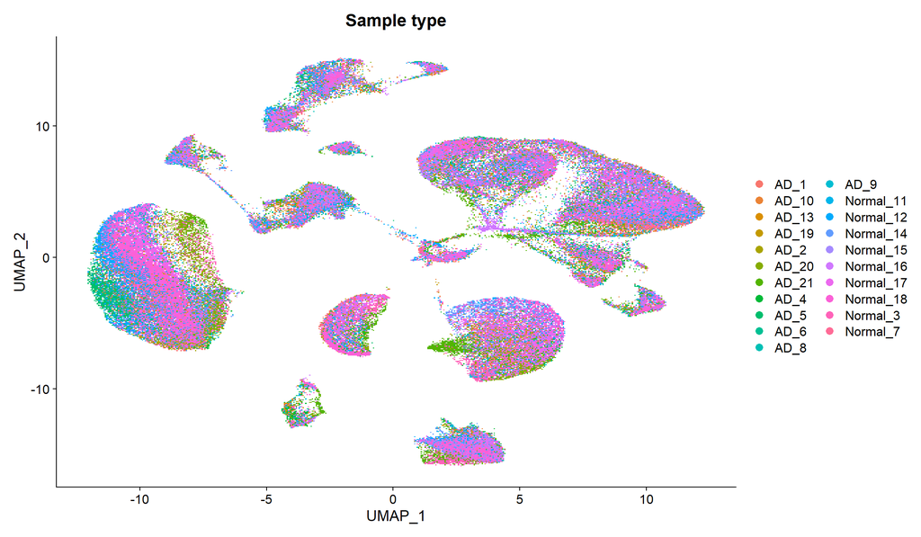

```r
DimPlot(merged_data_new_sct, group.by='sample_ids', reduction='umap') +
  ggtitle('Sample type')
```

# Section 4- Cell Annotation

## Here we used the scSorter: single cell Sorter which is a popularly used marker based cell type annotation method.

Users might use different approaches such as FindMarkers function from Seurat or reference based annotation methods such as SingleR etc. Please keep the column name as **cell_type** in the metadata while using any annotation method.

Loading marker genes data

```r
anno <- read.csv("./anno.csv")
```

### Display marker genes across celltypes

We used marker-based cell annotation method (scSorter) for assigning cells to known cell type. The markers genes for each cell type were added from Lau et al. (2020).

```r
anno %>%
  kable(format = "html", col.names = colnames(anno)) %>%
  kable_styling() %>%
  kableExtra::scroll_box(width = "100%", height = "400px")
```

| Type | Marker |
| --- | --- |
| Astro | AQP4 |
| Astro | ADGRV1 |
| Astro | GPC5 |
| Astro | RYR3 |
| Endo | CLDN5 |
| Endo | EBF1 |
| Endo | ABCB1 |
| Excit | CAMK2A |
| Excit | LDB2 |
| Excit | CBLN2 |
| Oligo | MBP |
| Oligo | PLP1 |
| Oligo | ST18 |
| Inhibit | LHFPL3 |
| Inhibit | GAD1 |
| Inhibit | PCDH15 |
| Mic | C3 |
| Mic | LRMDA |
| Mic | DOCK8 |

The scSorter method is a semi-supervised learning algorithm which expects the pre-processed data as input. The normalized and transformed expression matrix generated by SCT method is given as input. The scSorter method also allows to incorporate top variable genes selected by SCT method to be used as input.

```r
expr <- merged_data_new_sct@assays$SCT@data
topgenes <- head(merged_data_new_sct@assays$SCT@var.features, 3000)
topgene_filter = rowSums(expr[topgenes, ]!=0) > ncol(expr)*.1
topgenes = topgenes[topgene_filter]

## Subset the pre-processed expression data and run scSorter method.
picked_genes = unique(c(anno$Marker, topgenes))
expr = expr[rownames(expr) %in% picked_genes, ]
```

### Apply the scSorter method (fit)

Fit the scSorter method with the parameters as expression matrix and marker genes. The predicted cell type assignment results are stored in the rts object.

```r
rts <- scSorter(expr, anno)
merged_data_new_sct$cell_type <- rts$Pred_Type
gc()
```

```
##              used    (Mb) gc trigger    (Mb)   max used    (Mb)
## Ncells    8833974   471.8   17170554   917.1   17170554   917.1
## Vcells 2007666395 15317.3 5125004154 39100.7 5125000299 39100.7
```

### Cell type distribution

```r
table(rts$Pred_Type)
```

```
##
##   Astro    Endo   Excit Inhibit     Mic   Oligo Unknown
##   17594    2065   53549   27639    6599   39118    3227
```

### Add cell type information

The cell type information is added to the metadata information in the original Seurat object. Please note that the **cell_type** column is the naming convention for adding cell types in the shiny app.

```r
cell_type.info <- data.frame(cell_type = merged_data_new_sct$cell_type, row.names= colnames(merged_data_new_sct_umap))
merged_data_new_sct_umap <- AddMetaData(object = merged_data_new_sct_umap, metadata = cell_type.info)

## Convert cell type to factor
merged_data_new_sct_umap$cell_type <- as.factor(merged_data_new_sct_umap$cell_type)

Idents(merged_data_new_sct_umap) <- "cell_type"
```

### Stacked bar plot

Preparing the data for plotting cell type composition across different disease groups.

```r
df <- data.frame(merged_data_new_sct_umap@meta.data$cell_type, merged_data_new_sct_umap@meta.data$grp)
colnames(df) <- c("cell_type", "Condition")
df <- df %>% group_by(Condition, cell_type) %>%
  summarise(Nb = n()) %>%
  mutate(C = sum(Nb)) %>%
  mutate(Percent = Nb/C*100)

df<-df[df$cell_type!="Unknown",]
```

The stacked bar plot shows the cell type composition in disease and healthy group after pre-processing.

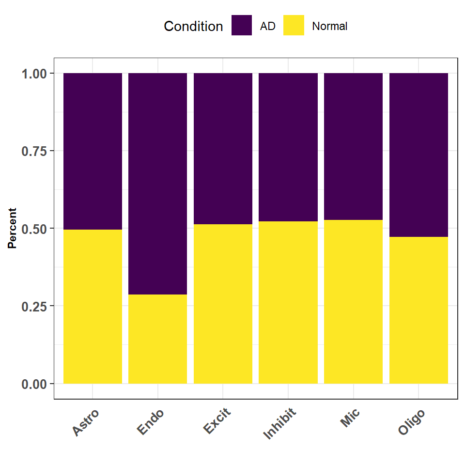

```r
xtheme <- theme_bw()+ theme(plot.title = element_text(face = "bold" ,hjust = 0.5, size= 10)
                            ,axis.text.y = element_text(face = "bold",angle = 0, size = 10, hjust=1)
                            ,axis.title.y = element_text(face = "bold", size = rel(0.8))
                            ,axis.text.x = element_text(face = "bold",angle = 0, size = 10)
                            ,axis.title.x = element_text(face = "bold", size = rel(0.8))
                            ,axis.ticks.x=element_blank(), strip.text = element_text(size=10))
ggplot(df, aes(fill=Condition, y=Percent, x=cell_type)) +
  geom_bar(position="fill", stat="identity") + scale_fill_viridis(discrete = T) + xlab("") + xtheme +
  theme(legend.position='top', axis.text.x = element_text(angle = 45, hjust = 1, vjust = 1))
```

## Check the expression of markers

### Below we show the expression of markers across the cell types

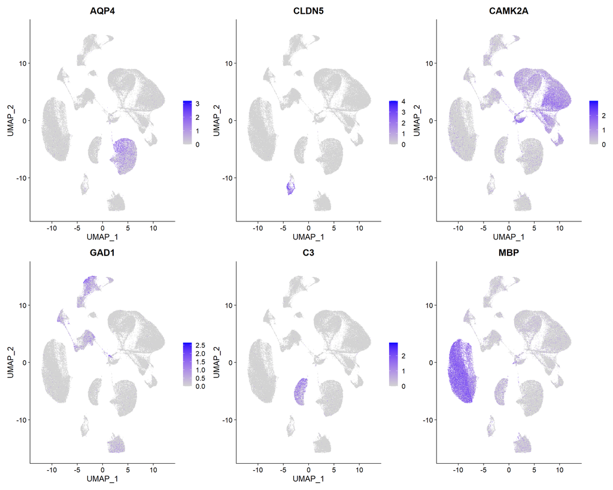

```r
FeaturePlot(merged_data_new_sct_umap, features = c("AQP4", "CLDN5", "CAMK2A", "GAD1", "C3",
                                             "MBP"), pt.size = 0.2, ncol = 3) + theme(legend.position = 'none',
                        axis.title.x = element_blank(), axis.title.y = element_blank())
```

The UMAP showing the cell type annotations from the scSorter method

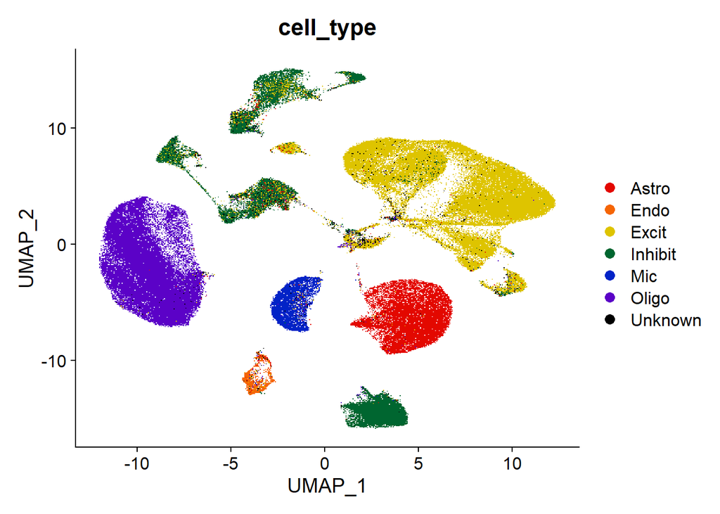

```r
DimPlot(merged_data_new_sct_umap, group.by = "cell_type", reduction = "umap", label = FALSE, cols= c("#e30800", "#f56505", "#dec400", "#006630", "#0223c7","#5b02c7", "#000000"))
```

### Below we show the UMAPs for the major cell types

UMAP showing only astrocyte cells

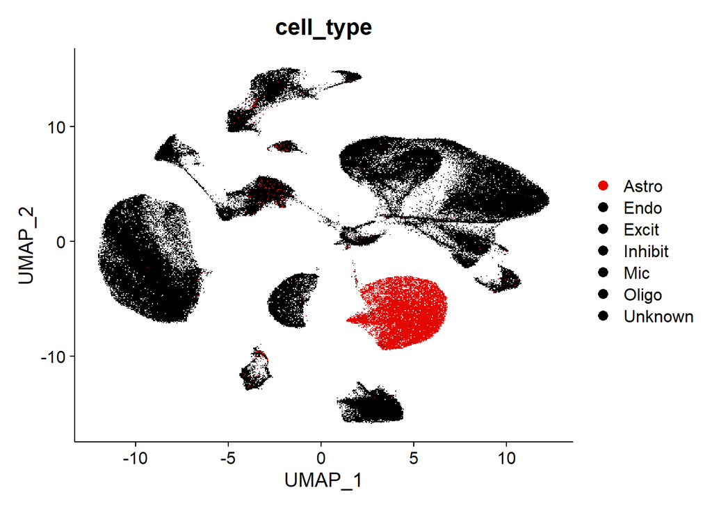

```r
DimPlot(merged_data_new_sct_umap, group.by = "cell_type", reduction = "umap", label = FALSE, cols= c("#e30800", "#000000", "#000000", "#000000", "#000000","#000000", "#000000"))
```

UMAP showing only endothelial cells

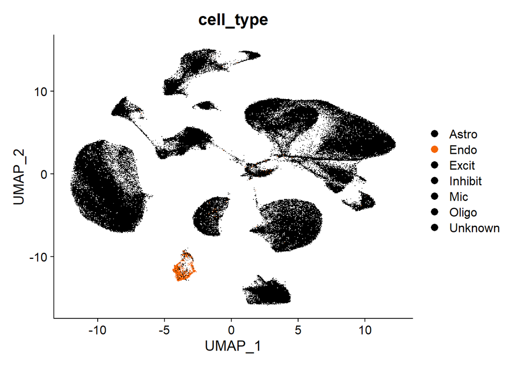

UMAP showing only excitatory neuronal cells

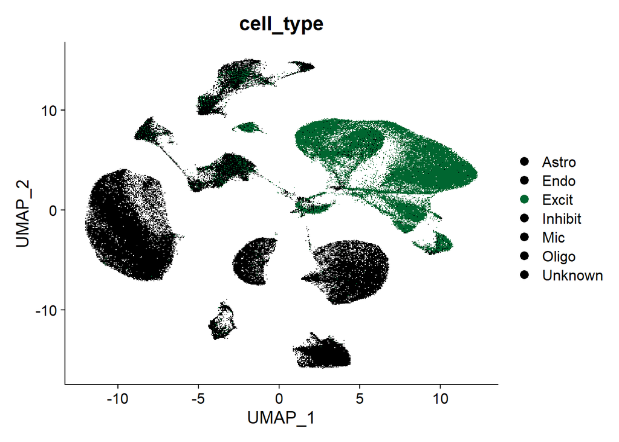

UMAP showing only microglia cells

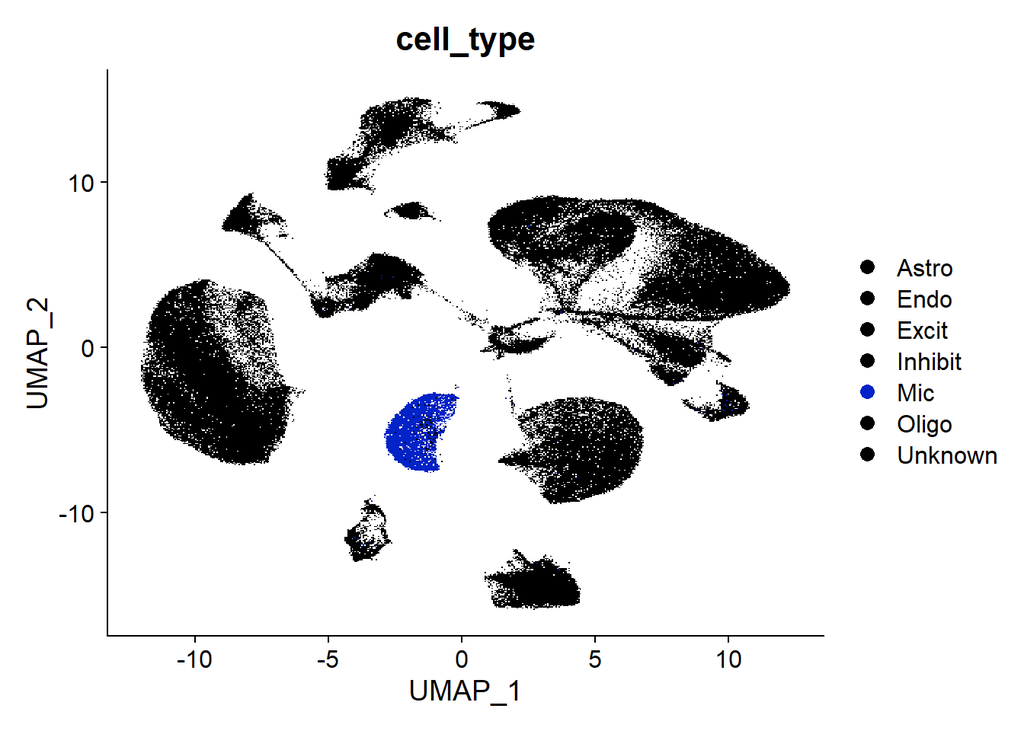

UMAP showing only oligodendrocytes cells

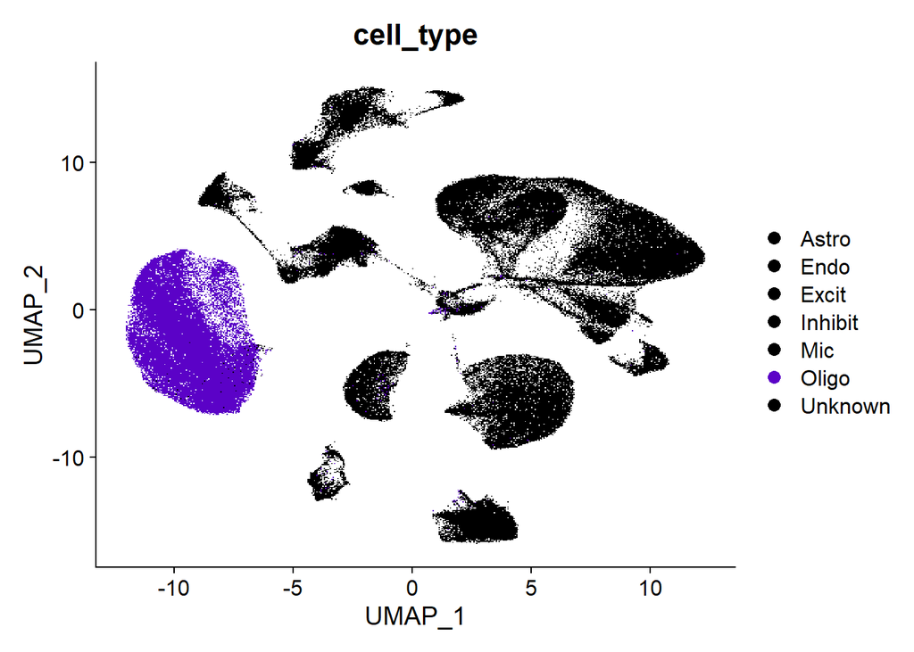

```r
rm(merged_data_new_sct)
## Remove unused variable from metadata.
merged_data_new_sct_umap$ident <- NULL
## Remove unknown cell types
merged_data_new_sct_umap <- subset(merged_data_new_sct_umap, subset = cell_type != "Unknown")
## Drop the level unknown from data
merged_data_new_sct_umap$cell_type <- droplevels(merged_data_new_sct_umap$cell_type)
saveRDS(merged_data_new_sct_umap, "E:/Users/APATIL34/GSE157827_RAW/sub/AD_Normal_GSE157827.rds")
```